# Elastic Net Logistic Regression - Identifing Cardiovascular Risk Factors in Prostate Cancer Patients on NHT

This notebook identifies baseline clinical factors associated with increased cardiovascular risk in prostate cancer patients on novel hormonal therapy (NHT). Cardiovascular risk is defined as a binary outcome ("at risk" vs. "no risk") based on new initiation of antihypertensive, lipid-lowering, or diabetes medications following NHT start.

We used an elastic net-penalized logistic regression with 5-fold cross-validation for variable selection across a broad set of clinical features, including demographics, comorbidities, baseline medications, tests, and referrals. Features selected by the elastic net are then passed to a standard logistic regression model to obtain odds ratios, confidence intervals, and p-values. Results are visualized as stratified bar charts comparing risk status across key predictors.

```python
import os
import numpy as np
import pandas as pd
import matplotlib.pyplot as plt
import statsmodels.api as sm

from sklearn.linear_model import LogisticRegressionCV
from sklearn.preprocessing import StandardScaler
from sklearn.preprocessing import OneHotEncoder
from sklearn.impute import SimpleImputer
from sklearn.pipeline import Pipeline
from sklearn.compose import ColumnTransformer
import matplotlib.pyplot as plt
```

```python
DATA_FILE = "../../data/processed/cardio_onc_prostate_06_broad_clean.csv"
OUT_DIR = "Results/ElasticNet"
SEED = 42

os.makedirs(OUT_DIR, exist_ok = True)
```

```python
df = pd.read_csv(DATA_FILE)

df["at_risk"] = (
    (df["bp_meds_post_binary"] == 1) |
    (df["lipid_meds_post_binary"] == 1) |
    (df["dm_meds_post_binary"] == 1)
).astype(int)
```

```python
continuous_features = [
    "bmi", "age", "sbp", "dbp", "ascvd_10yr"
]

binary_features = [
    "hx_smoking", "family_hx_hd", "hx_htn",
    "bp_meds_prior", "bb_prior", "ace_arb_prior",
    "has_pcp", "hx_hld", "hx_high_tg",
    "statin_prior", "other_lipid_prior", "lipid_panel_checked",
    "hx_cad", "hx_mi_stent", "hx_chf", "hx_arrhythmia",
    "hx_carotid", "hx_pad", "hx_cva",
    "hx_dm2", "dm_noninsulin", "on_insulin",
    "a1c_checked", "glucose_over_200",
    "asa_use", "cards_prior", "cards_post", "cards_referral",
    "diet_counseling", "exercise_counseling",
    "echo_ordered", "ecg_done", "non_onc_provider",
]

encoded_features = [
    "ethnicity_enc", "specific_nht_used_enc",
    "adt_agent_enc", "prescribing_provider_enc",
]

all_features = continuous_features + binary_features + encoded_features
```

```python
X_df = df[all_features].copy().astype(float)
y = df["at_risk"].values.astype(int)
X_arr = X_df.values
```

## Preprocess

```python
preprocessor = ColumnTransformer(
    transformers=[
        ("cont", Pipeline([
            ("impute", SimpleImputer(strategy="median")),
            ("scale", StandardScaler()),
        ]), continuous_features),

        ("binary", Pipeline([
            ("impute", SimpleImputer(strategy="most_frequent")),
        ]), binary_features),

        ("encoded", Pipeline([
            ("impute", SimpleImputer(strategy="most_frequent")),
            ("onehot", OneHotEncoder(drop="first", sparse_output=False, handle_unknown="ignore")),
        ]), encoded_features),
    ],
    remainder="drop",
)

X_processed = preprocessor.fit_transform(X_df)
```

## Model Fit

```python
model = LogisticRegressionCV(
    penalty='elasticnet',
    solver='saga',
    l1_ratios=[0.1, 0.5, 0.9],
    Cs=np.logspace(-4, 2, 50),
    cv=5,
    scoring='roc_auc',
    max_iter=10000,
    random_state=42,
    class_weight="balanced"
)

model.fit(X_processed, y)
```

```
LogisticRegressionCV(Cs=array([1.00000000e-04, 1.32571137e-04, 1.75751062e-04, 2.32995181e-04,
       3.08884360e-04, 4.09491506e-04, 5.42867544e-04, 7.19685673e-04,
       9.54095476e-04, 1.26485522e-03, 1.67683294e-03, 2.22299648e-03,
       2.94705170e-03, 3.90693994e-03, 5.17947468e-03, 6.86648845e-03,
       9.10298178e-03, 1.20679264e-02, 1.59985872e-02, 2.12095089e-02,
       2.81176870e-02, 3.72...
       8.28642773e-01, 1.09854114e+00, 1.45634848e+00, 1.93069773e+00,
       2.55954792e+00, 3.39322177e+00, 4.49843267e+00, 5.96362332e+00,
       7.90604321e+00, 1.04811313e+01, 1.38949549e+01, 1.84206997e+01,
       2.44205309e+01, 3.23745754e+01, 4.29193426e+01, 5.68986603e+01,
       7.54312006e+01, 1.00000000e+02]),
                     class_weight='balanced', cv=5, l1_ratios=[0.1, 0.5, 0.9],
                     max_iter=10000, penalty='elasticnet', random_state=42,
                     scoring='roc_auc', solver='saga')
```

## Extract Associations

```python
# Get feature names from the preprocessor
onehot_features = preprocessor.named_transformers_['encoded']['onehot'].get_feature_names_out(encoded_features).tolist()
all_processed_features = continuous_features + binary_features + onehot_features

# Build the dataframe
coef_df = pd.DataFrame({
    'feature':    all_processed_features,
    'log_odds':   model.coef_[0],
    'odds_ratio': np.exp(model.coef_[0])
}).query('log_odds != 0').sort_values('log_odds', key=abs, ascending=False)
```

## Errors & P-values

```python
X_processed_df = pd.DataFrame(X_processed, columns=all_processed_features)

selected = coef_df['feature'].tolist()
X_sel = sm.add_constant(X_processed_df[selected])

logit_model = sm.Logit(y, X_sel).fit()
print(logit_model.summary())

odds_ratios = pd.DataFrame({
    'OR':     np.exp(logit_model.params),
    'CI_low': np.exp(logit_model.conf_int()[0]),
    'CI_high':np.exp(logit_model.conf_int()[1]),
    'p_value':logit_model.pvalues
})
```

```
Optimization terminated successfully.
         Current function value: 0.549146
         Iterations 5
                           Logit Regression Results
==============================================================================
Dep. Variable:                      y   No. Observations:                  239
Model:                          Logit   Df Residuals:                      233
Method:                           MLE   Df Model:                            5
Date:                Thu, 11 Jun 2026   Pseudo R-squ.:                  0.1346
Time:                        00:00:42   Log-Likelihood:                -131.25
converged:                       True   LL-Null:                       -151.66
Covariance Type:            nonrobust   LLR p-value:                 1.016e-07
=======================================================================================
                          coef    std err          z      P>|z|      [0.025      0.975]
---------------------------------------------------------------------------------------
const                  -1.3700      0.323     -4.240      0.000      -2.003      -0.737
dm_noninsulin           0.6288      0.189      3.331      0.001       0.259       0.999
bp_meds_prior           0.3663      0.184      1.987      0.047       0.005       0.727
hx_smoking              0.3941      0.268      1.469      0.142      -0.132       0.920
ethnicity_enc_2.0      -0.5139      0.311     -1.654      0.098      -1.123       0.095
lipid_panel_checked     0.8340      0.356      2.342      0.019       0.136       1.532
=======================================================================================
```

## Conclusion

Lipid panel checked, non-insulin diabetes medication, and prior BP meds have the strongest association with risk, with p-values less than 0.05.

Health history of smoking is suggestive but not significant.

## Visualize Results

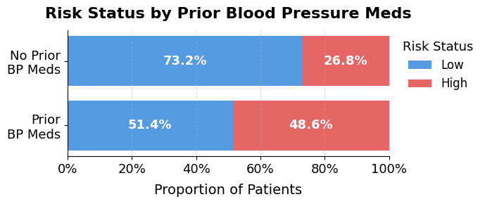

```python
bp_labels = {1: 'Prior BP Meds', 0: 'No Prior BP Meds'}
df['bp_meds_label'] = df['bp_meds_prior'].map(bp_labels)

risk_labels = {0: 'Low', 1: 'High'}
df['risk_label'] = df['at_risk'].map(risk_labels)

risk_groups = ['Low', 'High']
colors = ['#378ADD', '#E24B4A']

y_cats = ['Prior BP Meds', 'No Prior BP Meds']
y_pos = [0, 0.45]

prop_data = {}
for cat in y_cats:
    subset = df[df['bp_meds_label'] == cat]
    total = len(subset)
    prop_data[cat] = {risk: (subset['risk_label'] == risk).sum() / total * 100
                      for risk in risk_groups}

fig, ax = plt.subplots(figsize=(7, 3))

lefts = np.zeros(len(y_cats))
for i, risk in enumerate(risk_groups):
    values = [prop_data[cat][risk] for cat in y_cats]
    bars = ax.barh(y_pos, values, left=lefts, color=colors[i],
                   alpha=0.85, label=str(risk), height=0.35)

    for bar, val in zip(bars, values):
        if val > 5:
            ax.text(bar.get_x() + bar.get_width() / 2,
                    bar.get_y() + bar.get_height() / 2,
                    f'{val:.1f}%', ha='center', va='center',
                    fontsize=13, color='white', fontweight='bold')
    lefts += values

ax.set_xlim(0, 100)
ax.set_yticks(y_pos)
ax.set_yticklabels(['Prior\nBP Meds', 'No Prior\nBP Meds'], fontsize=13)
ax.xaxis.set_major_formatter(plt.FuncFormatter(lambda x, _: f'{x:.0f}%'))
ax.tick_params(axis='x', labelsize=13)
ax.set_xlabel('Proportion of Patients', fontsize=14, labelpad=8)
ax.set_title('Risk Status by Prior Blood Pressure Meds', fontsize=16,
             fontweight='bold', pad=12)

ax.spines['top'].set_visible(False)
ax.spines['right'].set_visible(False)
ax.grid(axis='x', linestyle='--', alpha=0.4)
ax.legend(title='Risk Status', fontsize=12, title_fontsize=13,
          frameon=False, bbox_to_anchor=(1.01, 1), loc='upper left')

plt.tight_layout()
plt.show()
```

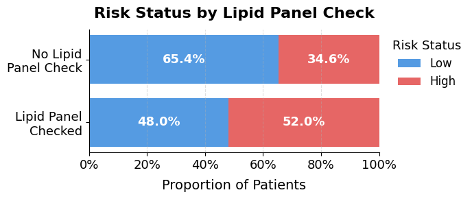

```python
lipid_labels = {1: 'Lipid Panel Checked', 0: 'No Lipid Panel Check'}
df['lipid_label'] = df['lipid_panel_checked'].map(lipid_labels)

risk_labels = {0: 'Low', 1: 'High'}
df['risk_label'] = df['at_risk'].map(risk_labels)

risk_groups = ['Low', 'High']
colors = ['#378ADD', '#E24B4A']

y_cats = ['Lipid Panel Checked', 'No Lipid Panel Check']
y_pos = [0, 0.45]

prop_data = {}
for cat in y_cats:
    subset = df[df['lipid_label'] == cat]
    total = len(subset)
    prop_data[cat] = {risk: (subset['risk_label'] == risk).sum() / total * 100
                      for risk in risk_groups}

fig, ax = plt.subplots(figsize=(7, 3))

lefts = np.zeros(len(y_cats))
for i, risk in enumerate(risk_groups):
    values = [prop_data[cat][risk] for cat in y_cats]
    bars = ax.barh(y_pos, values, left=lefts, color=colors[i],
                   alpha=0.85, label=str(risk), height=0.35)

    for bar, val in zip(bars, values):
        if val > 5:
            ax.text(bar.get_x() + bar.get_width() / 2,
                    bar.get_y() + bar.get_height() / 2,
                    f'{val:.1f}%', ha='center', va='center',
                    fontsize=13, color='white', fontweight='bold')
    lefts += values

ax.set_xlim(0, 100)
ax.set_yticks(y_pos)
ax.set_yticklabels(['Lipid Panel\nChecked', 'No Lipid\nPanel Check'], fontsize=13)
ax.xaxis.set_major_formatter(plt.FuncFormatter(lambda x, _: f'{x:.0f}%'))
ax.tick_params(axis='x', labelsize=13)
ax.set_xlabel('Proportion of Patients', fontsize=14, labelpad=8)
ax.set_title('Risk Status by Lipid Panel Check', fontsize=16,
             fontweight='bold', pad=12)

ax.spines['top'].set_visible(False)
ax.spines['right'].set_visible(False)
ax.grid(axis='x', linestyle='--', alpha=0.4)
ax.legend(title='Risk Status', fontsize=12, title_fontsize=13,
          frameon=False, bbox_to_anchor=(1.01, 1), loc='upper left')

plt.tight_layout()
plt.show()
```

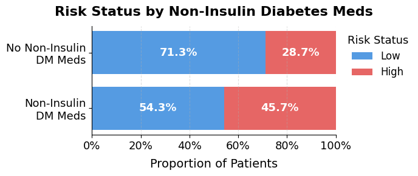

```python
dm_labels = {1: 'Non-Insulin DM Meds', 0: 'No Non-Insulin DM Meds'}
df['dm_meds_label'] = df['dm_noninsulin'].map(dm_labels)

risk_labels = {0: 'Low', 1: 'High'}
df['risk_label'] = df['at_risk'].map(risk_labels)

risk_groups = ['Low', 'High']
colors = ['#378ADD', '#E24B4A']

y_cats = ['Non-Insulin DM Meds', 'No Non-Insulin DM Meds']
y_pos = [0, 0.45]

prop_data = {}
for cat in y_cats:
    subset = df[df['dm_meds_label'] == cat]
    total = len(subset)
    prop_data[cat] = {risk: (subset['risk_label'] == risk).sum() / total * 100
                      for risk in risk_groups}

fig, ax = plt.subplots(figsize=(7, 3))

lefts = np.zeros(len(y_cats))
for i, risk in enumerate(risk_groups):
    values = [prop_data[cat][risk] for cat in y_cats]
    bars = ax.barh(y_pos, values, left=lefts, color=colors[i],
                   alpha=0.85, label=str(risk), height=0.35)

    for bar, val in zip(bars, values):
        if val > 5:
            ax.text(bar.get_x() + bar.get_width() / 2,
                    bar.get_y() + bar.get_height() / 2,
                    f'{val:.1f}%', ha='center', va='center',
                    fontsize=13, color='white', fontweight='bold')
    lefts += values

ax.set_xlim(0, 100)
ax.set_yticks(y_pos)
ax.set_yticklabels(['Non-Insulin\nDM Meds', 'No Non-Insulin\nDM Meds'], fontsize=13)
ax.xaxis.set_major_formatter(plt.FuncFormatter(lambda x, _: f'{x:.0f}%'))
ax.tick_params(axis='x', labelsize=13)
ax.set_xlabel('Proportion of Patients', fontsize=14, labelpad=8)
ax.set_title('Risk Status by Non-Insulin Diabetes Meds', fontsize=16,
             fontweight='bold', pad=12)

ax.spines['top'].set_visible(False)
ax.spines['right'].set_visible(False)
ax.grid(axis='x', linestyle='--', alpha=0.4)
ax.legend(title='Risk Status', fontsize=12, title_fontsize=13,
          frameon=False, bbox_to_anchor=(1.01, 1), loc='upper left')

plt.tight_layout()
plt.show()
```

### Current Runtime: 36 sec